# Part II - Prosper Loan Data Exploration

## Presented by Monica Iddah

## Investigation Overview

The goal of this investigation is to give an insight into why some loan application were successful over the others.

I explored the given dataset upon their available variables and we concluded that the successful loan applications were of borrowers whose status of employment, monthly income and sources of income have been verrified.

## Dataset Overview

The loan application system contains 113,937 applications with 81 different types of information or variables. The variables in the dataset include but not limited to:(ListingCreationDate, ListingNumber, ListingKey, EmploymentStatus, EmploymentStatusDuration, Occupation, IncomeRange, StatedMonthlyIncome, IncomeVerifiable, LoanOriginalAmount, LoanOriginationDate, MonthlyLoanPayment, DateCreditPulled, Recommendations, LoanStatus, Term, PercentFunded, ClosedDate, IsBorrowerHomeowner, InvestmentFromFriendsCount, InvestmentFromFriendsAmount, Investors).

The datatypes of some of the variables were changed and reordered to suite my anaylysis.

The dataset would be explored upon the listed variables in the following three dimensions (Univariate, Bivariate and Multivariate exploration) inorder to achieve the correlation and relationship there exist amongst the dataset.

### How many percentage of Borrowers were employed to other status

*The statistics below shows about 59.08% were employed.*

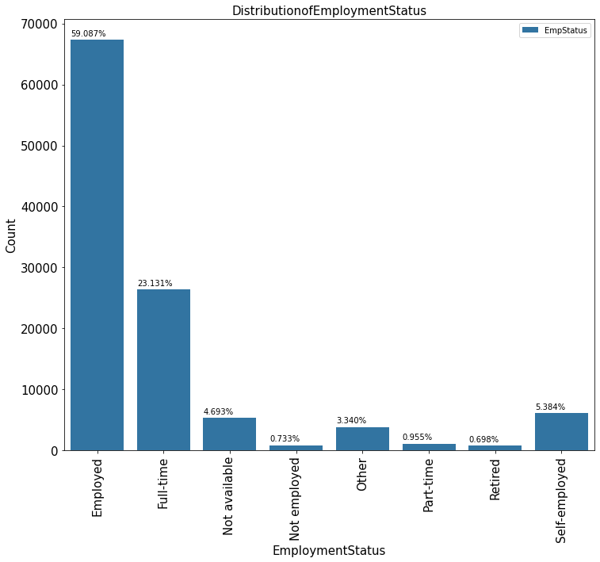

### What is the distribution of income verrified to the unverified?

The below charts shows more than 100,000, income of Borrowers have been verified, leading to a successful loan refund.

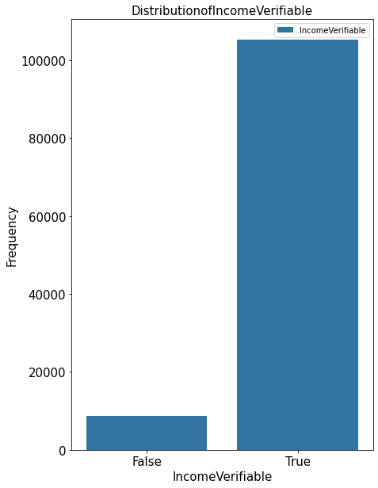

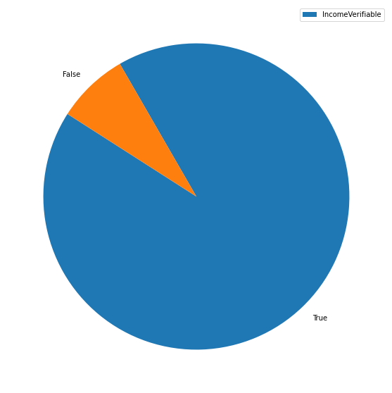

### What is the employment status of the borrowers verrified income?

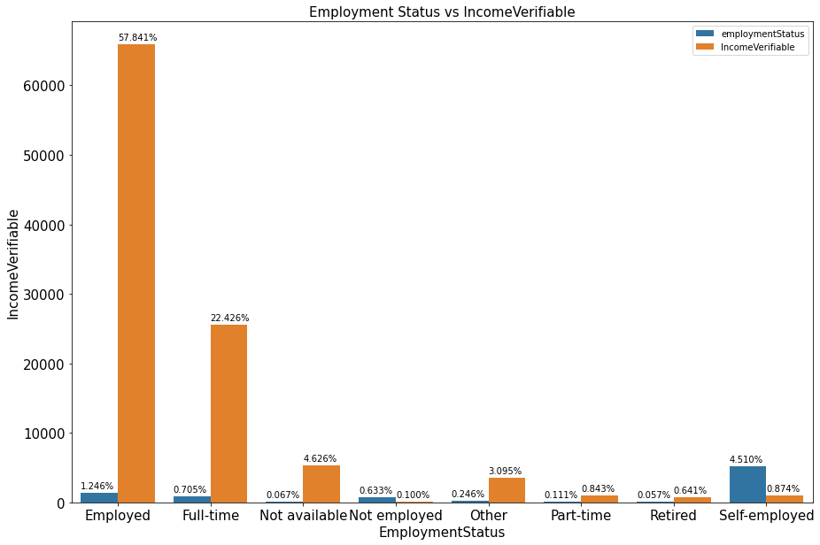

### What is the status of loan qpplied for from the listing numbers provided?

According to the listing numbers which uniquely identifies a loan request, we can identify the borrowers whose loan request have been completed, just through their unique ID's and not having to go through their names.

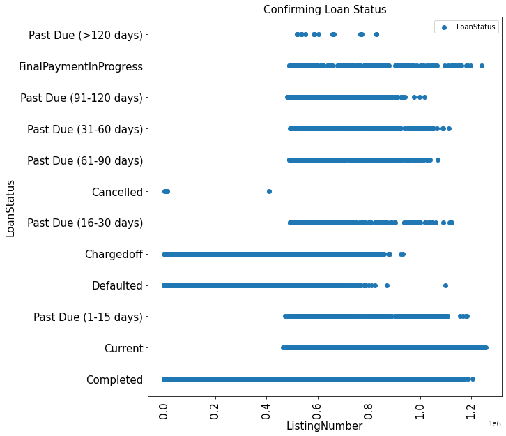

### What is the distribution of the loan created date, what are the amounts requested for and what are their current satus?

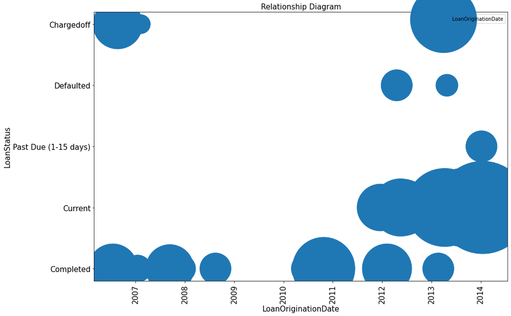

### What is the loan original amount, what is the status of the loan and when was the loan closed?

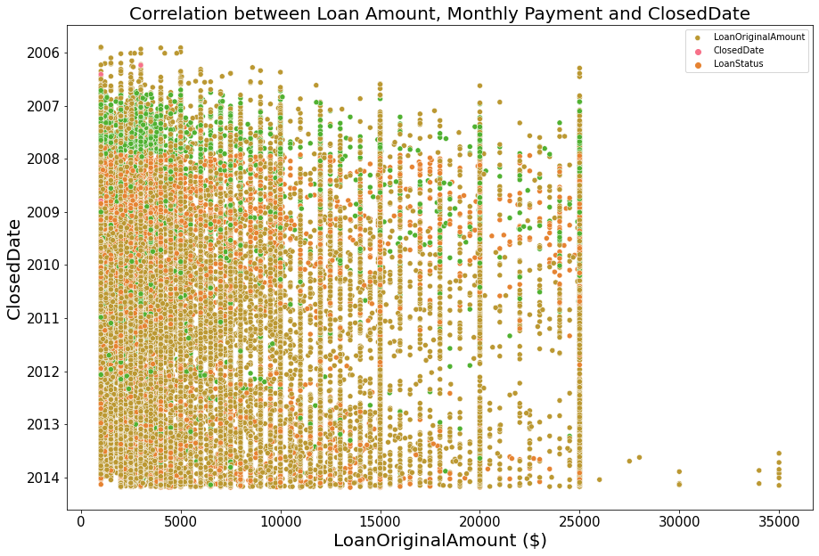